# Introduction to RamEx

More complete information about how to use RamEx can be found in the [github](https://github.com/qibebt-bioinfo/RamEx), but here you’ll find a brief overview of the function and examples to mining of ramanomes:

# Installaiton

```r
# library(devtools)
# install_github("qibebt-bioinfo/RamEx")
```

# Getting Started

## Data Loading

Raman spectra are respectively tracked in single txt files, and their meta info is recorded in the file name.

```r
library(RamEx)
library(dplyr)
data(RamEx_data)
options(mc.cores = 2)
```

## Pretreatment

Spectral pretreatment will make the spectrum clearer, containing smoothing, baseline removal, normalization and truncation. Mean spectra will display their effects. Here the results of each step will be kept in the Ramanome for better debugging, and ‘plot’ exhibit the final dataset.

```r
RamEx_data <- RamEx_data %>% Preprocessing.Smooth.Sg %>% Preprocessing.Baseline.Polyfit %>% Preprocessing.Normalize(.,'ch')
```

```
## The Ramanome contains 500 spectra
```

```
## [1] "0h"   "20h"  "60h"  "100h"
```

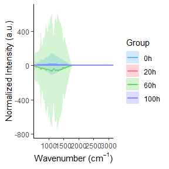

```r
plot(RamEx_data)
```

## Quality control

Remove the samples with low quality or abnormal spectral acquisition. ICOD method is recommended to perform quality control (QC). Each method will return a logical vector, indicating the quality of each cell sample.

```
## [1] "0h"   "20h"  "60h"  "100h"
```

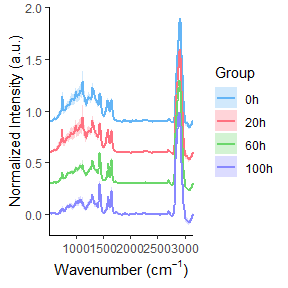

```r
qc_icod <- Qualitycontrol.ICOD(RamEx_data)
data_cleaned <- RamEx_data[qc_icod$quality,]
plot(data_cleaned)
```

```r
qc_mcd <- Qualitycontrol.Mcd(RamEx_data)
qc_t2 <- Qualitycontrol.T2(RamEx_data)
qc_dis <- Qualitycontrol.Dis(RamEx_data)
qc_snr <- Qualitycontrol.Snr(RamEx_data, 'easy')
```

## Interested Bands

Get single-cell intensitiy or intensity accumulationy within a wavenumber range, pls give a list containing multiple bands or band ranges. These feature selection results will be saved as ‘interested.bands’ in the given Ramanome object. Further, you can add some equations by yourself (e.g. calculate CDR).

```r
data_cleaned <- Feature.Reduction.Intensity(data_cleaned, list(c(2000,2250),c(2750,3050), 1450, 1665))
# calculate CDR
CDR <- data.frame(data_cleaned@meta.data,
                  data_cleaned$`2000~2250`/(data_cleaned$`2000~2250` + data_cleaned$`2750~3050`))
```

## Reduction

Nonlinear methods, such as UMAP and t-SNE. Linear methods like PCA, pCoA. The reduced sample matrix will be contained in the Ramanome onject as ‘reductions’. Attention: A pre-treatment of large spectral matrix by PCA is recommended, since UMAP and t-SNE are highly complex algorithms.

```r
data.reduction <- Feature.Reduction.Pca(data_cleaned) %>% Feature.Reduction.Pcoa %>% Feature.Reduction.Tsne %>% Feature.Reduction.Umap
```

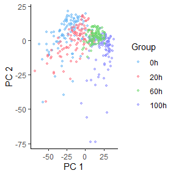

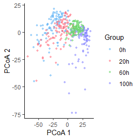

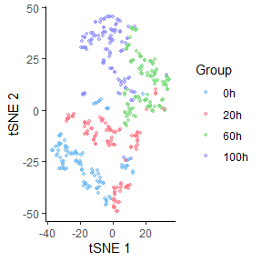

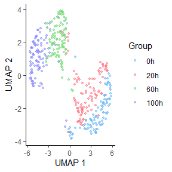

## Markers analysis

RamEx provides three types of markers analysis: ROC, correlation and RBCS. In addition to singular Raman markers, paired bands are also examined

```r
ROC_markers <- Raman.Markers.Roc(Preprocessing.Cutoff(data_cleaned, 1400, 1500), paired  = T, threshold = 0.6)
```

```
## Finding singular markers ...
## Finding paired markers ...
## This may take a while, please be patient ...
```

```r
cor_markers <- Raman.Markers.Correlations(Preprocessing.Cutoff(data_cleaned, 1400, 1500), min.cor = 0.6)
```

```
## Finding singular markers ...
```

```r
RBCS.markers <- Raman.Markers.Rbcs(data_cleaned, threshold = 0.003, show = T)
```

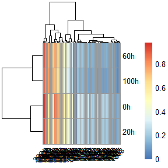

## IRCA

Observe the single-cell heterogeneity within the Ramanome/microbial community and to elucidate intracellular metabolite conversions.

### Global IRCA.

```r
IRCA.interests <- Intraramanome.Analysis.Irca.Global(data_cleaned)
```

```
## It may take a while to drawing the plot, please be patient.
```

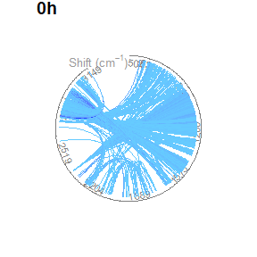

```
## It may take a while to drawing the plot, please be patient.
```

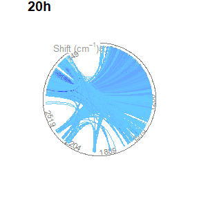

```
## It may take a while to drawing the plot, please be patient.
```

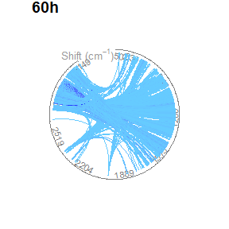

```
## It may take a while to drawing the plot, please be patient.
```

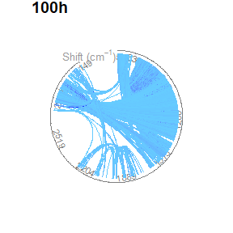

### Local IRCA

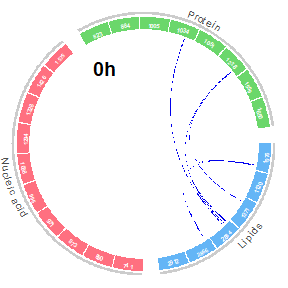

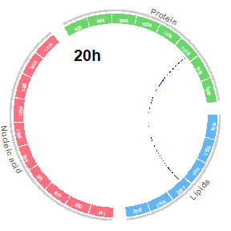

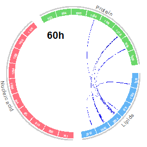

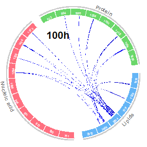

```r
bands_ann <- data.frame(
  Wave_num = c(742,850,872,971,997,1098,1293,1328,1426,1576,
               824,883,1005,1033,1051,1237,1559,1651,
               1076,1119,1370,2834,2866,2912),
  Group = rep(c('Nucleic acid', 'Protein', 'Lipids'), times = c(10, 8, 6)) )
Intraramanome.Analysis.Irca.Local(data_cleaned, bands_ann = bands_ann)
```

### 2D-COS

Captures both synchronous (simultaneous changes) and asynchronous (sequential changes) relationships, providing detailed insights into spectral changes

```r
data_cos <- Intraramanome.Analysis.2Dcos(data_cleaned)
```

```
## HOMO-Correlation: 20 cores used for calculation
## 15:26:10 - using mean values as reference
## 15:26:10 - Fast Fourier Transformation and multiplication
##  to obtain a 1318 x 1318 correlation matrix
## 15:26:16 - Done
```

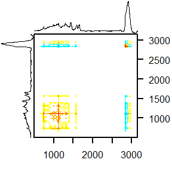

## Phenotype analysis

RamEx provides four types of phenotype analysis: Louvain clustering, K-means clustering, Gaussian mixture model and hierarchical clustering.

```r
clusters_louvain <- Phenotype.Analysis.Louvaincluster(object = data_cleaned, resolutions = c(0.8))
```

```
## Creating the communities...
## Processing resolution: 0.8
## Merging the isolate samples...
```

```r
clusters_kmneans <- Phenotype.Analysis.Kmeans(data_cleaned,5)
clusters_gmm <- Phenotype.Analysis.Gmm(data_cleaned)
clusters_hca <- Phenotype.Analysis.Hca(data_cleaned)
```

## Classifications

Linear Discriminant Analysis (LDA), Random Forest (RF), Support Vector Machine (SVM)

```r
model.lda <- Classification.Lda(data_cleaned)
```

```
## Training accuracy of PC-LDA: 0.9103943
## Test accuracy of PC-LDA: 0.9583333
```

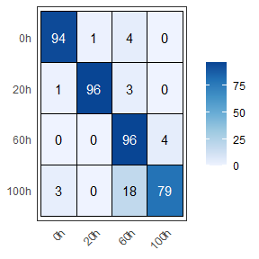

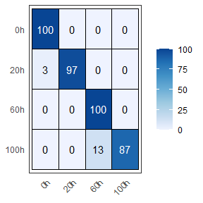

```r
model.rf <- Classification.Rf(data_cleaned)
```

```
## Training accuracy of Random forest: 1
## Test accuracy of Random forest: 0.925
```

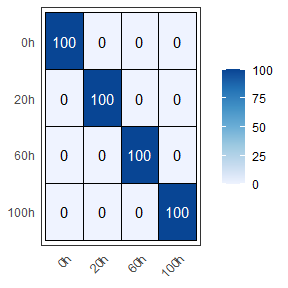

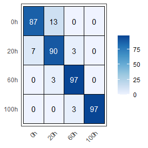

```r
model.svm <- Classification.Svm(data_cleaned)
```

```
## Training accuracy of SVM: 1
## Test accuracy of SVM: 0.975
```

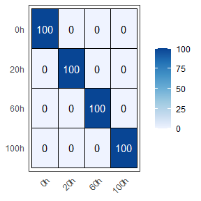

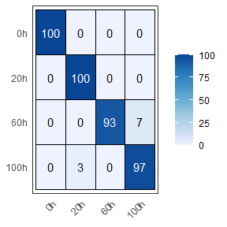

```r
# when new data is available, you can use the following code to predict the new data by using the trained model.
pred_new <- predict_classification(model.lda, data_cleaned)
```

```
## 0.924812
```

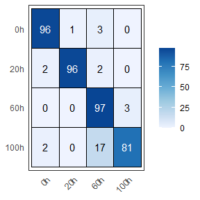

## Quantifications

Partial Least Squares (PLS), Multiple Linear Regression (MLR), Generalized Linear Model (GLM)

```r
quan_pls <- Quantification.Pls(data_cleaned)
```

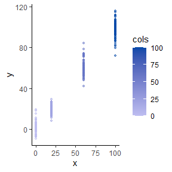

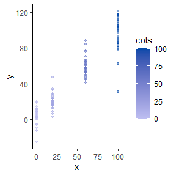

```r
quan_mlr <- Quantification.Mlr(data_cleaned)
```

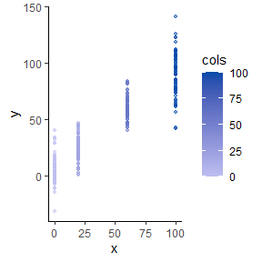

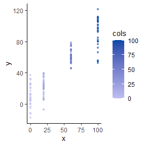

```r
quan_glm <- Quantification.Glm(data_cleaned)
```

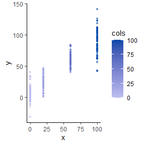

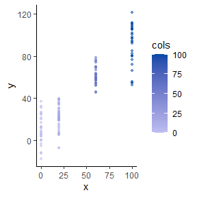

```r
# when new data is available, you can use the following code to predict the new data by using the trained model.
pred_new <- predict_quantification(quan_pls, data_cleaned)
```

## Spectral decomposition

Multiple Component Regression - Alternating Least Squares (MCR-ALS), Independent Component Analysis (ICA), Non-negative Matrix Factorization (NMF) are provide to decompose the spectral matrix into multiple components.

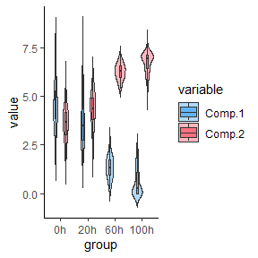

```r
decom_mcr <- Spectral.Decomposition.Mcrals(data_cleaned,n_comp = 2)
decom_ica <- Spectral.Decomposition.Ica(data_cleaned, n_comp = 2)
decom_nmf <- Spectral.Decomposition.Nmf(data_cleaned, n_comp = 2)
Plot.ViolinBox(decom_mcr$concentration, data_cleaned$group)
```

```r
mean.spec(t(decom_mcr$components), factor(c('Comp.1','Comp.2')),gap=0)
```

```
## [1] "Comp.1" "Comp.2"
```

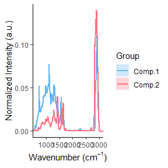